# MATH 3070 Lab Project 3

Kanishka Ragula

September 1, 2016

*Remember: I expect to see commentary either in the text, in the code with comments created using `#`, or (preferably) both! **Failing to do so may result in lost points!***

## Problem 1

*The `faithful` (Package **datasets** is built in Base R) dataset records the waiting time between eruptions and the duration of the eruption for the Old Faithful geyser in Yellowstone National Park. Find the mean waiting time, median waiting time, longest waiting time and shortest waiting time in minutes.*

```r
library(UsingR)
#Prints mean
mean(faithful$waiting)
```

```
## [1] 70.89706
```

```r
#Prints median
median(faithful$waiting)
```

```
## [1] 76
```

```r
#Prints max
max(faithful$waiting)
```

```
## [1] 96
```

```r
#Prints min
min(faithful$waiting)
```

```
## [1] 43
```

## Problem 2 (Verzani problem 2.34)

*The data set `DDT` (**MASS**) contains independent measurements of the pesticide DDT on kale. Make a histogram and a boxplot of the data. From these, estimate the mean and standard deviation. Check your answers with the appropriate functions.*

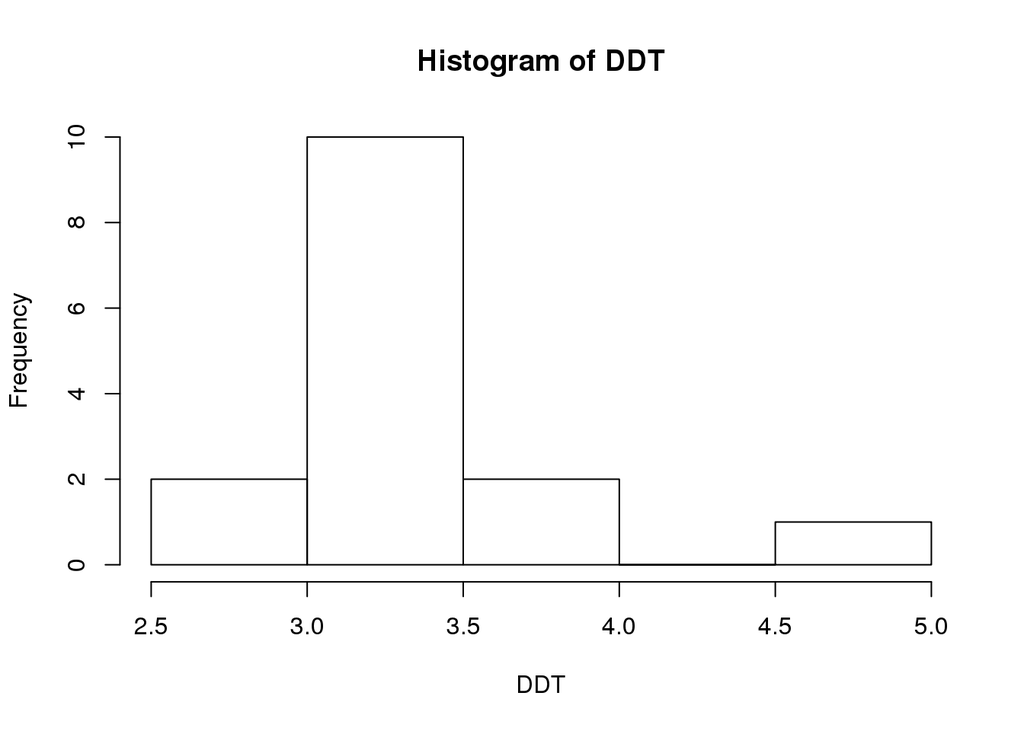

```r
#Creates a Histogram of DDT
hist(DDT)
```

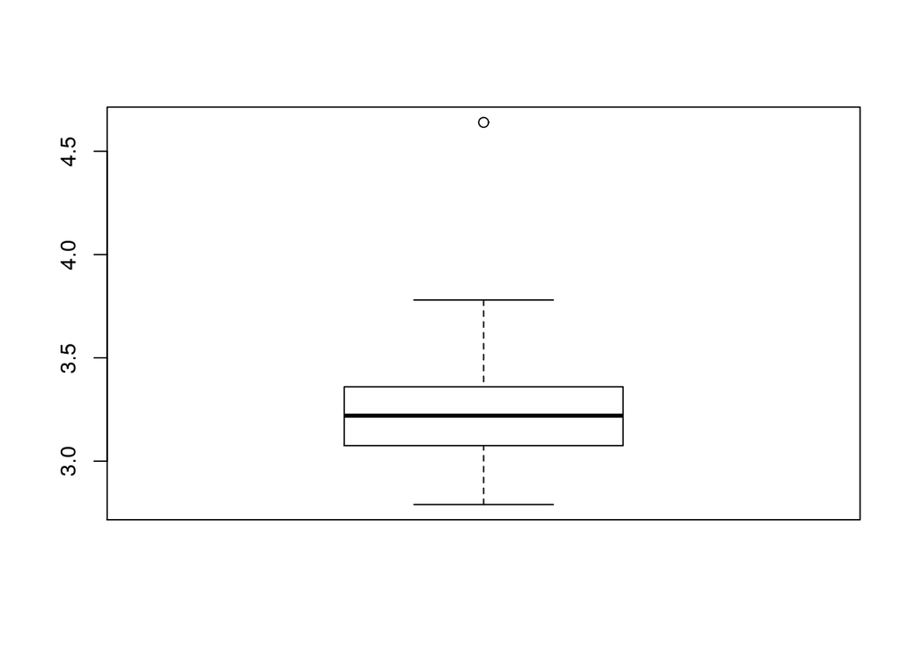

```r
#Creates a Boxplot for DDT
boxplot(DDT)
```

```r
#Calculates mean of DDT
mean(DDT)
```

```
## [1] 3.328
```

```r
#Calculates standard Deviation of DDT
sd(DDT)
```

```
## [1] 0.4371531
```